# Language Model

Natural Language Processing (NLP) describes the field of Artificial Intelligence dealing with textual data. In this chapter we study a particular application of this field called Language Modeling (LM). LM consists in building models that have to output the next word given a context, a collection of previous words. Such model is trained to maximize the probability of the next word in a given dictionary. LM can be used for User Interfaces where the model can help the user wrtie text faster, in text generation tasks to generate new sentences in the style of a given writer and more.

Here we attempt to build a Language Model based on J. K. Rowling's Harry Potter Books.

```python
from __future__ import annotations

from collections import Counter, OrderedDict
from nltk.tokenize import sent_tokenize, word_tokenize
from torch import Tensor
from torch.nn import Embedding, GRU, Linear, LSTM, Module, PairwiseDistance, Parameter, ReLU, RNN, Sequential
from torch.optim import AdamW, Optimizer
from torch.utils.data import DataLoader, Dataset
from tqdm.notebook import tqdm

import matplotlib.pyplot as plt
import numpy as np
import num2words
import os
import torch
import torch.nn.functional as F
import re
import requests

%matplotlib inline
```

## Data

This section describes the data processing and the building of the dataset for training our LM.

### Curation

The Harry Potter Books class is responsible for collecting all the Harry Potter books and assemble them into one text file to be further processed.

```python
class HarryPotterBooks:
    base = "https://raw.githubusercontent.com/formcept/whiteboard/master/nbviewer/notebooks/data/harrypotter"
    urls = [
        os.path.join(base, "Book%201%20-%20The%20Philosopher's%20Stone.txt"),
        os.path.join(base, "Book%202%20-%20The%20Chamber%20of%20Secrets.txt"),
        os.path.join(base, "Book%203%20-%20The%20Prisoner%20of%20Azkaban.txt"),
        os.path.join(base, "Book%204%20-%20The%20Goblet%20of%20Fire.txt"),
        os.path.join(base, "Book%205%20-%20The%20Order%20of%20the%20Phoenix.txt"),
        os.path.join(base, "Book%206%20-%20The%20Half%20Blood%20Prince.txt"),
        os.path.join(base, "Book%207%20-%20The%20Deathly%20Hallows.txt"),
    ]

    def __init__(self, path: str, download: bool = True) -> None:
        self.path = path
        if download: self._download()

    def _download(self) -> None:
        if not os.path.isfile(self.path):
            with open(self.path, "a") as fp:
                for hp_book_url in self.urls:
                    request = requests.get(hp_book_url, allow_redirects=True)
                    fp.write(request.content.decode("utf-8"))

    def read_lines(self) -> list[str]:
        with open(self.path, "r") as fp:
            return fp.readlines()
```

### Preprocessing

The Preprocessor class provides methods to help in the preprocessing of the books. It is reponsible for removing the empty lines, removing unnecessary informations such as the chapter number, replacing abbreviations by their full versions, and removing the end of line symbols.

```python
class HarryPotterLinePreprocessor:
    @staticmethod
    def remove_empty_lines(lines: list[str]) -> list[str]:
        return [l for l in lines if l not in ["/ \n", "\n"]]

    @staticmethod
    def remove_chapter_names(lines: list[str]) -> list[str]:
        return [l for l in lines if sum((c.isupper() or c in [" ", "\n"] for c in l)) != len(l)]

    @staticmethod
    def remove_page_declaration(lines: list[str]) -> list[str]:
        return [l for l in lines if not (l.startswith("Page | ") or l.endswith("J.K. Rowling "))]

    @staticmethod
    def to_lowercase(lines: list[str]) -> list[str]:
        return [l.lower() for l in lines]

    @staticmethod
    def replace_symbols(lines: list[str]) -> list[str]:
        lines = list(lines)
        for abbr, full in {
            "“"          : "\"",
            "”"          : "\"",
            "''"         : "\"",
            "``"         : "\"",
            "’’"         : "\"",
            "'"          : "'",
            "`"          : "'",
            "’"          : "'",
            "jr."        : "junior",
            "sr."        : "senior",
            "mr."        : "mister",
            "mrs."       : "miss",
            "dr."        : "doctor",
            "don't"      : "do not",
            "won't"      : "will not",
            "wouldn't"   : "would not",
            "shouldn't"  : "should not",
            "isn't"      : "is not",
            "wasn't"     : "was not",
            "can't"      : "cannot",
            "i'm"        : "i am",
            "you're"     : "you are",
            "you'd"      : "you would",
            "we're"      : "we are",
            "they're"    : "they are",
            "that's"     : "that is",
            "there's"    : "there is",
            "who's"      : "who is",
            "what's"     : "what is",
            "where's"    : "where is",
            "how's"      : "how is",
            "let's"      : "let us",
            "i've"       : "i have",
            "i'd"        : "i had",
            "haven't"    : "have not",
            "hadn't"     : "had not",
            "hasn't"     : "has not",
            "aint't"     : "am not",
            "shouldn’ta" :"should not you",
        }.items(): lines = [l.replace(abbr, full) for l in lines]
        return lines

    @staticmethod
    def replace_numbers(lines: list[str]) -> list[str]:
        replace = lambda x: num2words.num2words(int(x.group(0)))
        return [re.sub(r"\d+", replace, l) for l in lines]

    @staticmethod
    def remove_end_of_line(lines: list[str]) -> list[str]:
        return [l.replace("\n", "").strip() for l in lines]

    @staticmethod
    def preprocess(lines: list[str], join: bool = True) -> list[str] | str:
        lines = HarryPotterLinePreprocessor.remove_empty_lines(lines)
        lines = HarryPotterLinePreprocessor.remove_end_of_line(lines)
        lines = HarryPotterLinePreprocessor.remove_chapter_names(lines)
        lines = HarryPotterLinePreprocessor.remove_page_declaration(lines)
        lines = HarryPotterLinePreprocessor.to_lowercase(lines)
        lines = HarryPotterLinePreprocessor.replace_numbers(lines)
        lines = HarryPotterLinePreprocessor.replace_symbols(lines)
        return " ".join(lines) if join else lines
```

### Processor

The Processor class provides methods for splitting the raw text into word tokens and further process them.

```python
class HarryPotterProcessor:
    @staticmethod
    def extract_tokens(raw: str) -> list[str]:
        return word_tokenize(raw, language="english")

    @staticmethod
    def extract(raw: str) -> list[str]:
        return HarryPotterProcessor.extract_tokens(raw)
```

### Vocabulary

The Vocab class represents the dictionary of token, the vocabulary available for the model. It automatically builds itself from the collection of tokens provided and generates two useful mappings, from token string to index, and from token index to string.

```python
class Vocab:
    def __init__(self, tokens: list[str], min_freq: int) -> None:
        self.tokens, self.min_freq = tokens, min_freq
        self._stoi = {s: i for i, (s, count) in enumerate(self._token_freq_pairs()) if count >= min_freq}
        self._itos = {i: s for s, i in self._stoi.items()}

    def _token_freq_pairs(self) -> list[tuple[str, int]]:
        return list(OrderedDict(Counter(self.tokens).most_common()).items())

    def __len__(self) -> int: return len(self._stoi)
    def stoi(self, s: str) -> int: return self._stoi[s]
    def itos(self, i: int) -> str: return self._itos[i]
```

### Dataset

The Dataset class acts as a data iterator for the LM building task. It generates pairs of context tokens and a corresponding next word token for every possible fitting window in the provided token collection. It makes use of the preprocessorn and the processor to build a vocabulary as well as the training pairs.

An optional `prop` (proportion) argument can be passed to the constructor to limit the dataset to a certain proportion of its full length. This property can be helpful for training LM models on a smaller set, and iterate faster by limitting the amount of data.

```python
class HarryPotterNextTokenDataset(Dataset):
    def __init__(self, path: str, context_size: int, prop: float = 1.0) -> None:
        super().__init__()
        self.path = path
        self.context_size = context_size
        self.window_size = context_size + 1
        self.prop = prop

        self.lines  = HarryPotterBooks(path, download=True).read_lines()
        self.raw = HarryPotterLinePreprocessor.preprocess(self.lines, join=True)
        self.tokens = HarryPotterProcessor.extract(self.raw)
        self.tokens = self.tokens[:int(self.prop * len(self.tokens))]
        self.vocab = Vocab(self.tokens, min_freq=1)
        self.pairs: list[tuple[list[int], int]]  = []

        for start in range(len(self.tokens) - self.window_size):
            end = start + self.window_size
            window = self.tokens[start:end]
            self.pairs.append((window[:-1], window[-1]))

    def __len__(self) -> int:
        return len(self.pairs)

    def __getitem__(self, idx: int) -> tuple[Tensor, int]:
        ctx, word = self.pairs[idx]
        ctx = torch.tensor([self.vocab.stoi(token) for token in ctx], dtype=torch.long)
        word = self.vocab.stoi(word)
        return ctx, word
```

```python
class HarryPotterTokenDatasets:
    dataset_path = os.path.join(".datasets", "hp.txt")
    tiny  = HarryPotterNextTokenDataset(dataset_path,  1)
    small = HarryPotterNextTokenDataset(dataset_path,  8)
    big   = HarryPotterNextTokenDataset(dataset_path, 16)
    huge  = HarryPotterNextTokenDataset(dataset_path, 32)
```

```python
dataset = HarryPotterTokenDatasets.big
for i in range(12):
    ctx, word = dataset[i]
    idxs = ctx.tolist() + [word]
    tokens = map(lambda idx: dataset.vocab.itos(idx), idxs)
    print(" ".join([f"[{idx}]{token}" for idx, token in zip(idxs, tokens)]), "[end]")
```

```
[133]mister [5]and [150]miss [1285]dursley [0], [7]of [618]number [479]four [0], [1303]privet [1008]drive [0], [42]were [1852]proud [6]to [184]say [19]that [end]
[5]and [150]miss [1285]dursley [0], [7]of [618]number [479]four [0], [1303]privet [1008]drive [0], [42]were [1852]proud [6]to [184]say [19]that [30]they [end]
[150]miss [1285]dursley [0], [7]of [618]number [479]four [0], [1303]privet [1008]drive [0], [42]were [1852]proud [6]to [184]say [19]that [30]they [42]were [end]
[1285]dursley [0], [7]of [618]number [479]four [0], [1303]privet [1008]drive [0], [42]were [1852]proud [6]to [184]say [19]that [30]they [42]were [1166]perfectly [end]
[0], [7]of [618]number [479]four [0], [1303]privet [1008]drive [0], [42]were [1852]proud [6]to [184]say [19]that [30]they [42]were [1166]perfectly [1080]normal [end]
[7]of [618]number [479]four [0], [1303]privet [1008]drive [0], [42]were [1852]proud [6]to [184]say [19]that [30]they [42]were [1166]perfectly [1080]normal [0], [end]
[618]number [479]four [0], [1303]privet [1008]drive [0], [42]were [1852]proud [6]to [184]say [19]that [30]they [42]were [1166]perfectly [1080]normal [0], [762]thank [end]
[479]four [0], [1303]privet [1008]drive [0], [42]were [1852]proud [6]to [184]say [19]that [30]they [42]were [1166]perfectly [1080]normal [0], [762]thank [15]you [end]
[0], [1303]privet [1008]drive [0], [42]were [1852]proud [6]to [184]say [19]that [30]they [42]were [1166]perfectly [1080]normal [0], [762]thank [15]you [86]very [end]
[1303]privet [1008]drive [0], [42]were [1852]proud [6]to [184]say [19]that [30]they [42]were [1166]perfectly [1080]normal [0], [762]thank [15]you [86]very [156]much [end]
[1008]drive [0], [42]were [1852]proud [6]to [184]say [19]that [30]they [42]were [1166]perfectly [1080]normal [0], [762]thank [15]you [86]very [156]much [1]. [end]
[0], [42]were [1852]proud [6]to [184]say [19]that [30]they [42]were [1166]perfectly [1080]normal [0], [762]thank [15]you [86]very [156]much [1]. [30]they [end]
```

## Helper

The history serves the same purpose as for the previous chapters. It will hold and accumulate the metrics during training and allow to plot them in a summary graph. Here we are interested in the loss and the accruacy. Of course we could montior other textual metrics such as the perplexity, the blue score, the red score or others.

```python
class History:
    def __init__(self) -> None:
        self.loss = []
        self.acc = []

    def __len__(self) -> int:
        assert len(self.loss) == len(self.acc)
        return len(self.loss)

    def plot(self) -> None:
        fig = plt.figure(figsize=(2 * 4, 4), dpi=400)
        ax = fig.add_subplot(2, 1, 1)
        ax.plot(list(range(len(self))), self.loss, label="train", color="r")
        ax.set_title("Loss History")
        ax.set_xlabel("epoch")
        ax.set_ylabel("loss")
        ax.grid(linestyle="--", linewidth=0.5)
        ax.spines["top"].set_visible(False)
        ax.spines["right"].set_visible(False)
        ax.spines["bottom"].set_visible(False)
        ax.spines["left"].set_visible(False)
        ax = fig.add_subplot(2, 1, 2)
        ax.plot(list(range(len(self))), self.acc, label="train", color="b")
        ax.set_title("Accuracy History")
        ax.set_xlabel("epoch")
        ax.set_ylabel("accuracy in %")
        ax.set_ylim(0.0, 100.0)
        ax.grid(linestyle="--", linewidth=0.5)
        ax.spines["top"].set_visible(False)
        ax.spines["right"].set_visible(False)
        ax.spines["bottom"].set_visible(False)
        ax.spines["left"].set_visible(False)
        fig.canvas.draw()
        fig.tight_layout()
        plt.show()
```

## Language Modeling

In this section, we study different type of Language Models, their advantages and drawbacks. The Language Model class handle the role of a common Interface for all the LM we build in the following sections.

```python
class LanguageModel(Module):
    def __init__(self, dataset: HarryPotterNextTokenDataset) -> None:
        super().__init__()
        self.dataset = dataset
        self.vocab = self.dataset.vocab

    def forward(self, x: Tensor, h: None | Tensor | tuple[Tensor, Tensor]) -> tuple[Tensor, None | Tensor | tuple[Tensor, Tensor]]:
        raise NotImplementedError

    @property
    def device(self) -> torch.DeviceObjType:
        return next(self.parameters()).device

    @property
    def vocab_size(self) -> int:
        return len(self.vocab)
```

We augment the LM class with a general fitting function as it will be the same for each and every LM version we build later. The fit function is responsible for training the LM model given an optimizer and common training hyperparemters. In this chapter we add a early stop mechanisme to stop trainning if no imporvement is made for a given amount of training epochs. This is not required bu will help us cut the training cost as the textual LM dataset are usually big.

```python
def fit(self: LanguageModel, optim: Optimizer, epochs: int, batch_size: int, idle_threshold: int = 4) -> History:
    loader = DataLoader(
        self.dataset,
        batch_size=batch_size,
        num_workers=4,
        pin_memory=True,
        shuffle=True,
        drop_last=True,
    )

    history = History()
    with tqdm(range(epochs), desc="Epoch") as pbar:
        best_state_dict, best_acc, best_step = {}, 0.0, 0
        for epoch in pbar:
            avg_loss, avg_acc = 0.0, 0.0
            for ctx, word in loader:
                ctx, word = ctx.to(self.device), word.to(self.device)

                y_, _ = self(ctx)
                loss = F.cross_entropy(y_, word)
                acc = (y_.argmax(dim=-1) == word).sum()

                optim.zero_grad(set_to_none=None)
                loss.backward()
                optim.step()

                avg_loss += loss.item() / len(loader)
                avg_acc  += acc.item()  / len(loader.dataset)

            history.loss.append(avg_loss)
            history.acc.append(avg_acc * 100)
            pbar.set_postfix(loss=f"{avg_loss:.2e}", acc=f"{avg_acc * 100:.2f}%")

            if avg_acc > best_acc:
                best_acc, best_step = avg_acc, 0
                best_state_dict = self.state_dict()
            else: best_step += 1

            if best_step >= idle_threshold:
                print(f"Training Stop Not Improving Since {best_step} Steps")
                break

    self.load_state_dict(best_state_dict)
    return history

LanguageModel.fit = fit
```

To make our generation method general, we assume that every language model outputs a tuple of Tensor (token probabilities), and the model's current internal sttate if any (set to `None` else).

```python
@torch.inference_mode()
def generate(self: LanguageModel, *ctx: tuple[str], length: int, temperature: float = 1.0, top_k: int = 1) -> list[str]:
    ctx, tokens = list(ctx), list(ctx)

    ctx, h = torch.tensor([self.vocab.stoi(t) for t in ctx], dtype=torch.long, device=self.device).unsqueeze(0), None
    for _ in range(length):
        logits, h = self(ctx, h)
        logits: Tensor = logits.squeeze(0) / temperature

        if top_k > 1:
            values, _ = torch.topk(logits, top_k)
            logits[logits < values[-1]] = -float("inf")

        probs: Tensor = torch.softmax(logits, dim=-1)
        idx = torch.multinomial(probs, num_samples=1) if top_k > 1 else probs.argmax()

        word = self.vocab.itos(idx.item())
        tokens.append(word)

        ctx[:, :-1] = ctx[:, 1:].clone()
        ctx[:, -1] = idx.clone()

    return tokens

LanguageModel.generate = generate
```

### Bigram

One of the simplest LM one can think of is a transition probability map from one token to every others. It is equivalent to considering a context of size one and can be represented as a Transition Matrix. It is called a Bigram model. This Transition matrix can be sampled given a token to produce the next one. This idea can further be extended to bigger contexts.

Formulating the problem of LM as an optimization problem, it is possible to build such a matrix iteratively and make it fit to a specific distribution style, the writting style of a writter for example.

```python
class BigramLM(LanguageModel):
    def __init__(self, dataset: HarryPotterNextTokenDataset) -> None:
        super().__init__(dataset)
        self.logits = Parameter(torch.zeros((self.vocab_size, self.vocab_size)))

    def forward(self, x: Tensor, h: None = None) -> tuple[Tensor, None]:
        return self.logits[x.view(-1)], None
```

In the following cell, we augment the Bigram model with a `plot` method that enables visualization of the inner Transition Matrix.

```python
def plot(self: BigramLM, limit: int = 200) -> None:
    limit = 200
    heatmap = self.logits.cpu().detach().numpy().clip(0, 1)[:limit, :limit]
    words = list(self.vocab._stoi.keys())[:limit]

    fig = plt.figure(figsize=(8, 8), dpi=600)
    ax = fig.add_subplot(1, 1, 1)
    im = ax.imshow(heatmap)
    ax.set_title("Bigram Heatmap")
    ax.tick_params(axis="both", which="both", length=0)
    ax.set_xticklabels(words, fontsize=2, rotation=90)
    ax.set_yticklabels(words, fontsize=2)
    ax.set_xticks(range(limit))
    ax.set_yticks(range(limit))
    ax.spines["top"].set_visible(False)
    ax.spines["right"].set_visible(False)
    ax.spines["bottom"].set_visible(False)
    ax.spines["left"].set_visible(False)
    fig.canvas.draw()
    plt.show()

BigramLM.plot = plot
```

#### Hyperparameters

```python
device = "cuda"
epochs = 100
batch_size = 512
lr = 1e-3
```

#### Training

```python
bigram = BigramLM(HarryPotterTokenDatasets.tiny).to(device)
optim = AdamW(bigram.parameters(), lr=lr)
```

```
Training Stop Not Improving Since 4 Steps
```

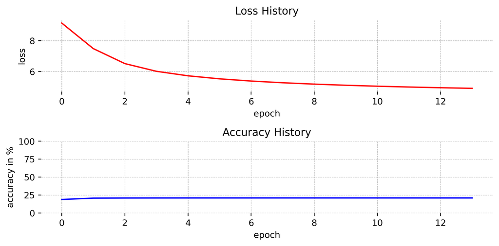

```python
bigram.fit(optim, epochs, batch_size).plot()
```

As it can be observed on the plot such a simple model cannot represent the complexity of the english language.

#### Transition Matrix

Here we visualize the Transition matrix for the first $200$ tokens.

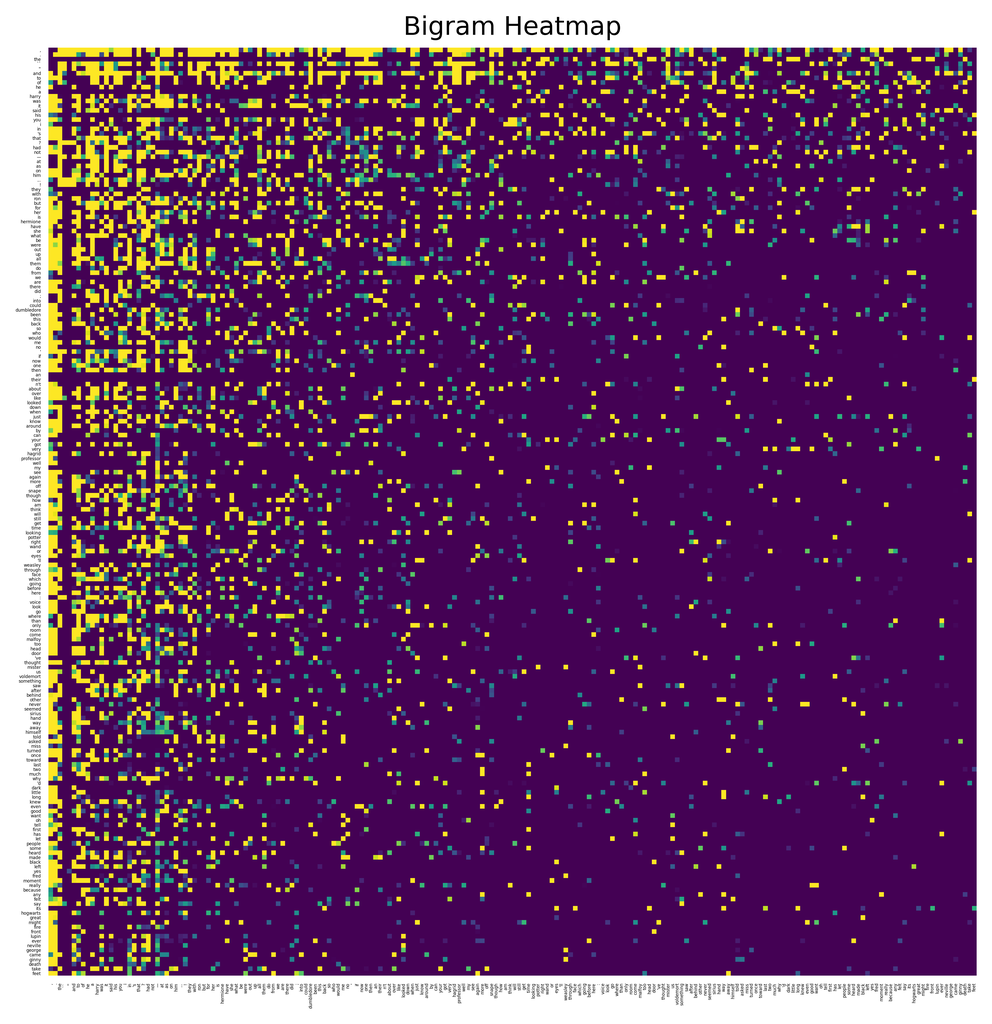

```python
bigram.plot(limit=200)
```

#### Sampling

In this subsection, we explore how the control parameters influence the generation capabilities of our model by prompting it with a size one context, an initial word to start a $10$ length text output.

```python
for temperature in [1.0, 0.8, 0.6, 0.4, 0.2]:
    for top_k in [1, 2, 4, 6, 8]:
        print(f"==== Bigram w/ Temperature: {temperature} and Top K: {top_k}")
        print(" ".join(bigram.generate("i",          length=10, temperature=temperature, top_k=top_k)))
        print(" ".join(bigram.generate("he",         length=10, temperature=temperature, top_k=top_k)))
        print(" ".join(bigram.generate("she",        length=10, temperature=temperature, top_k=top_k)))
        print(" ".join(bigram.generate("the",        length=10, temperature=temperature, top_k=top_k)))
        print(" ".join(bigram.generate("harry",      length=10, temperature=temperature, top_k=top_k)))
        print(" ".join(bigram.generate("gryffindor", length=10, temperature=temperature, top_k=top_k)))
        print(" ".join(bigram.generate("may",        length=10, temperature=temperature, top_k=top_k)))
        print()
```

```
==== Bigram w/ Temperature: 1.0 and Top K: 1
i am not know , '' said harry , '' said
he was a few seconds , '' said harry , ''
she was a few seconds , '' said harry , ''
the door . `` i am not know , '' said
harry , '' said harry , '' said harry , ''
gryffindor tower . `` i am not know , '' said
may i am not know , '' said harry , ''

==== Bigram w/ Temperature: 1.0 and Top K: 2
i have been a few seconds , and the door ,
he was a few days , '' `` i am not
she was a little more than ever . `` i am
the dark arts , '' said harry , '' `` you
harry . `` you are not know , '' said harry
gryffindor tower , '' said harry , and the door .
may i am not to the door , '' `` i

==== Bigram w/ Temperature: 1.0 and Top K: 4
i am sure he was a moment , and he was
he said harry 's a little more . `` i am
she had not to get out , '' harry , ''
the door , '' said harry potter , '' said hermione
harry potter , and he said , '' `` you ,
gryffindor tower , '' he was the door , '' said
may have to be in the dark mark , but he

==== Bigram w/ Temperature: 1.0 and Top K: 6
i do not be in his feet . `` i am
he was not think of a very well , but it
she was a very hard as though he was a little
the other hand and the door behind him , '' said
harry , and then he had been able to see him
gryffindor . the dark arts , but harry , and the
may i have got to get the other two of a

==== Bigram w/ Temperature: 1.0 and Top K: 8
i am going to do not you are you know where
he was a great hall . . `` he 'd be
she was in a large as though he could hear the
```

[output cut: 169 more lines]

```
he had been a little , '' said harry , ''
she said harry 's not to the other side of the
the goblet of the goblet of the door . `` i
harry , '' `` i am not know what is not
gryffindor tower . `` i am not know what is not
may i am not be able to the door . ``

==== Bigram w/ Temperature: 0.2 and Top K: 8
i am not be a few seconds , and the first
he had been a little more than ever , '' said
she was a few seconds later , '' said harry ,
the door . `` i am not to the first time
harry , '' said harry , '' said harry 's not
gryffindor tower , '' `` i am not want to the
may be a little , '' said harry , '' said
```

### Multi Layer Perceptron (MLP)

Another option for building a LM with the knowledge we acquired from the previous chapter is to use an Embedding to represent the words as compressed vectors in a trained latent space and use a MLP for classification. One drawback of such approach however is that the context size has to be fixed.

```python
class MultiLayerPerceptronLM(LanguageModel):
    def __init__(self, dataset: HarryPotterNextTokenDataset, emb_dim: int, h_dim: int) -> None:
        super().__init__(dataset)
        self.context_size = dataset.context_size
        self.embedding = Embedding(self.vocab_size, emb_dim)
        self.classifier = Sequential(
            Linear(emb_dim * self.context_size, h_dim), ReLU(),
            Linear(h_dim, self.vocab_size),
        )

    def forward(self, x: Tensor, h: None = None) -> tuple[Tensor, None]:
        x = self.embedding(x)
        x = x.reshape(x.size(0), -1)
        x = self.classifier(x)
        return x, None
```

#### Hyperparameters

```python
device = "cuda"
epochs = 200
batch_size = 512
lr = 1e-3

emb_dim = 512
h_dim = 128
```

#### Training

```python
mlp = MultiLayerPerceptronLM(HarryPotterTokenDatasets.small, emb_dim, h_dim).to(device)
optim = AdamW(mlp.parameters(), lr=lr)
```

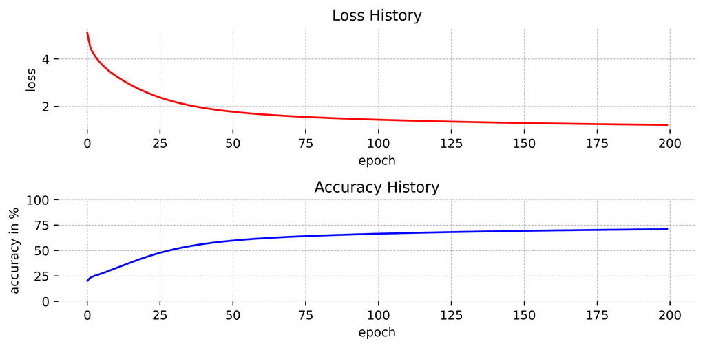

```python
mlp.fit(optim, epochs, batch_size).plot()
```

```python
print(" ".join(mlp.generate(*HarryPotterTokenDatasets.small.tokens[:HarryPotterTokenDatasets.small.context_size], length=100)))
print(" ".join(mlp.generate(*HarryPotterTokenDatasets.small.tokens[:HarryPotterTokenDatasets.small.context_size], length=100, temperature=0.8, top_k=5)))
```

```
mister and miss dursley , of number four , privet drive , because swept the way moody to check that point in rats , 'cause harry potter at the moment o cupboard hogwarts 's christmas of gryffindor has been cleaned through the mist of the international quidditch of the falling . miss weasley 's to po…
mister and miss dursley , of number four , privet drive , meaning — `` `` i 'll get other way out of the door . `` you know why to expel your lessons at all school about this . . '' `` yes , '' said harry . `` i have got to do with it , '' she said , `` but i mean , you would better take alastor to …
```

### Recurrent Neural Network (RNN)

MLPs are not designed to handle sequences of arbitrary size. [Recurrent Neural Networks (RNN)](https://apps.dtic.mil/dtic/tr/fulltext/u2/a164453.pdf) have been expecially designed to work with sequences. It consists of an MLP that takes two input, a query and a context that is updated at each input. This acts as a memory, a vector that compresses previous information. During the backward pass, the error gradient will be backproagated through time.

While this approach allows us to handle arbitrary large sequences, it suffers from known limitations. It suffers from exploding and vanishing gradients. If the gradient at timestep $t$ is two small, it will not propagate back through time anymore. It it is two big, in will corrupt the early steps. Although we said it allows us to handle arbitraty sized input sequences, because of such problems and because of the simple memory mechanism, this architecture fails at capturing long term dependencies.

```python
class RecurrentNeuralNetworkLM(LanguageModel):
    def __init__(self, dataset: HarryPotterNextTokenDataset, emb_dim: int, h_dim: int, rnn: type[Module], n_layers: int) -> None:
        super().__init__(dataset)
        self.embedding = Embedding(self.vocab_size, emb_dim)
        self.rnn = rnn(emb_dim, h_dim, num_layers=n_layers, batch_first=True)
        self.classifier = Linear(h_dim, self.vocab_size)

    def forward(self, x: Tensor, h: Tensor | tuple[Tensor, Tensor] = None) -> tuple[Tensor, Tensor | tuple[Tensor, Tensor]]:
        x = self.embedding(x)
        x, h = self.rnn(x, h)
        x = self.classifier(x[:, -1, :])
        return x, h
```

```python
device = "cuda"
epochs = 400
batch_size = 512
lr = 1e-3

emb_dim = 512
h_dim = 128
n_layers = 1
```

```python
rnn = RecurrentNeuralNetworkLM(HarryPotterTokenDatasets.big, emb_dim, h_dim, RNN, n_layers).to(device)
optim = AdamW(rnn.parameters(), lr=lr)
```

```
Training Stop Not Improving Since 4 Steps
```

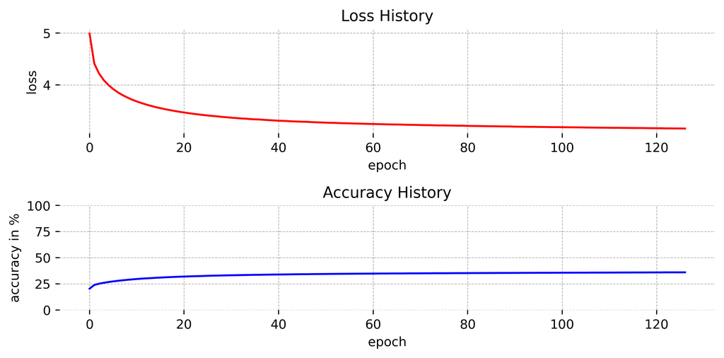

```python
rnn.fit(optim, epochs, batch_size).plot()
```

RNN seems harder to train, the memory mechanism may be two simple, or our context size two small to illustrate its benfits. You may try with a bigger input context.

```python
print(" ".join(rnn.generate(*HarryPotterTokenDatasets.big.tokens[:HarryPotterTokenDatasets.big.context_size], length=100)))
print(" ".join(rnn.generate(*HarryPotterTokenDatasets.big.tokens[:HarryPotterTokenDatasets.big.context_size], length=100, temperature=0.8, top_k=5)))
```

```
mister and miss dursley , of number four , privet drive , were proud to say , but he was not sure that he was not there , and he was going to be able to get to the dementors , '' said harry , `` but i am sure you are not going to be able to get to the library , '' said harry . `` i am not sure that …
mister and miss dursley , of number four , privet drive , were proud to say , `` but we can not have to tell me that i was just trying to make it easier to stop you , '' he said in an undertone , but he had never been able to see the snitch of their eyes and looked up . `` i am not sure you would be…
```

#### Long Short Term Memory (LSTM)

To counter the issues introduced by the Vanilla RNN, complex memory mechanisms have been introduced in the literature. One of them, certainly the most popular, is the [Long Short Term Memory (LSTM)](http://www.bioinf.jku.at/publications/older/2604.pdf). It uses several gating procedures to modify two states, one for short term memory and another for long term memory. The LSTM cell comprises $3$ gates, the forget gate to erase unecessary information from the long term memory given the current input and the previous short term state, an input gate to select which information to keep in memory, and lastly an output gate using the current states to output the next token.

Such complex machinery allows to go beyond the limitations of the vanilla RNN and handle up two a thousand length sequences depending on the task complexity.

```python
device = "cuda"
epochs = 400
batch_size = 512
lr = 1e-3

emb_dim = 512
h_dim = 128
n_layers = 1
```

```python
lstm = RecurrentNeuralNetworkLM(HarryPotterTokenDatasets.huge, emb_dim, h_dim, LSTM, n_layers).to(device)
optim = AdamW(lstm.parameters(), lr=lr)
```

```
Training Stop Not Improving Since 4 Steps
```

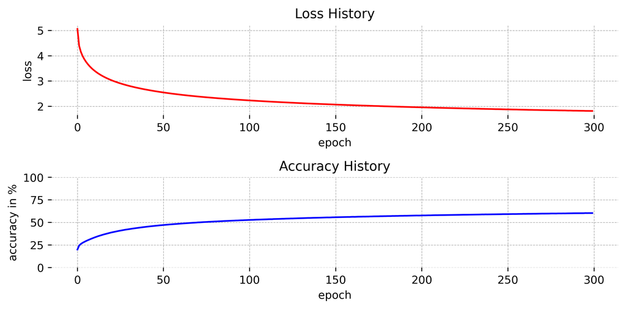

```python
lstm.fit(optim, epochs, batch_size).plot()
```

```python
print(" ".join(lstm.generate(*HarryPotterTokenDatasets.huge.tokens[:HarryPotterTokenDatasets.huge.context_size], length=200)))
print(" ".join(lstm.generate(*HarryPotterTokenDatasets.huge.tokens[:HarryPotterTokenDatasets.huge.context_size], length=200, temperature=0.8, top_k=5)))
```

```
mister and miss dursley , of number four , privet drive , were proud to say that they were perfectly normal , thank you very much . they were the last people in the common room when professor mcgonagall had given them the quibbler again . `` if she had been at hogwarts , of course , '' she said . ``…
mister and miss dursley , of number four , privet drive , were proud to say that they were perfectly normal , thank you very much . they were the last people in the hospital wing . professor slughorn was looking at miss weasley for a couple of years of years , however , had been quite a lot , with s…
```

#### Gated Recurrent Unit (GRU)

While the LSTM is a grate successor of the RNN cell, it does not come at no cost. It is heavier to compute as each gate involves a non linear layer with its weights. Simpler mechansims have been proposed to eleviate this problem. One of them is the [Gated Recurrent Unit (GRU)](https://arxiv.org/abs/1412.3555). The GRU sacrifices accuracy for speed.

```python
device = "cuda"
epochs = 400
batch_size = 512
lr = 1e-3

emb_dim = 512
h_dim = 128
n_layers = 1
```

```python
gru = RecurrentNeuralNetworkLM(HarryPotterTokenDatasets.huge, emb_dim, h_dim, GRU, n_layers).to(device)
optim = AdamW(gru.parameters(), lr=lr)
```

```
Training Stop Not Improving Since 4 Steps
```

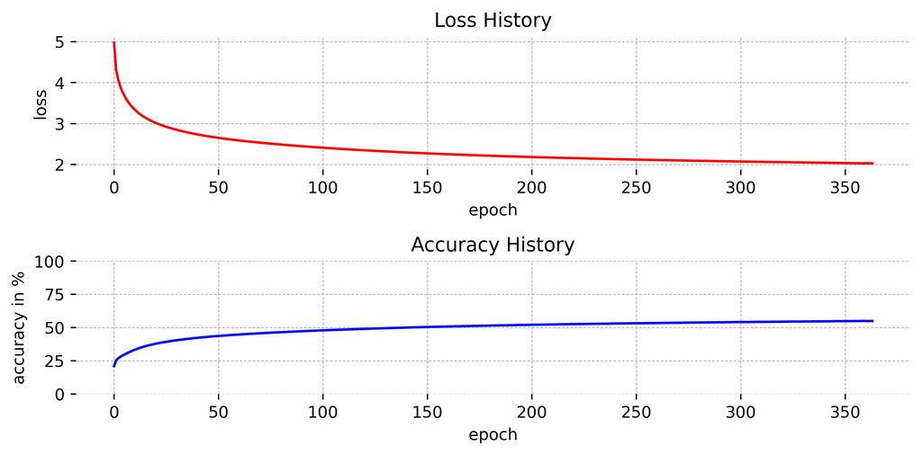

```python
gru.fit(optim, epochs, batch_size).plot()
```

```python
print(" ".join(gru.generate(*HarryPotterTokenDatasets.huge.tokens[:HarryPotterTokenDatasets.huge.context_size], length=200)))
print(" ".join(gru.generate(*HarryPotterTokenDatasets.huge.tokens[:HarryPotterTokenDatasets.huge.context_size], length=200, temperature=0.8, top_k=5)))
```

```
mister and miss dursley , of number four , privet drive , were proud to say that they were perfectly normal , thank you very much . they were the last people to arrive you were exploding for the food to which miss mason 's house and eleven stay , harry thought , as i should be able to tell you . '' …
mister and miss dursley , of number four , privet drive , were proud to say that they were perfectly normal , thank you very much . they were the last people arriving at the burrow , because fred and george weasley arrived here , trying to find the covers for him , would not sleep . he had not been …
```

### Attention Mechanism

Not every element of a sequence is important when taking a decision. When we, as humans, take a look at a sentence, we only focus on subsections of greater importance and use them as vectors for our context that allows us to answer questions on the nature of the data, and take informed decisions. This process is called Attention. Similar mechanisms have been created for sequence learning, such as the [Additive Attention](https://arxiv.org/abs/1409.0473v7), the [Multplicative Attention](https://arxiv.org/abs/1508.04025), more recently the [Self Attention](https://proceedings.neurips.cc/paper/2017/file/3f5ee243547dee91fbd053c1c4a845aa-Paper.pdf), and many others (e.g. Cross Attention).

Here we implement a simple Self Attention mechanism. As will see in the next chapters it is the building block for an entire state of the art architecture family, the Transformers.

```python
class Attention(Module):
    def __init__(self, h_dim: int) -> None:
        super().__init__()
        self.q = Linear(h_dim, h_dim)
        self.k = Linear(h_dim, h_dim)
        self.v = Linear(h_dim, h_dim)

    def forward(self, q: Tensor, k: Tensor, v: Tensor) -> Tensor:
        scale = 1. / np.sqrt(q.size(-1))
        q = q.transpose(0, 1)
        q, k, v = self.q(q), self.k(k), self.v(v)
        k = k.permute(0, 2, 1)
        e = torch.softmax(scale * torch.bmm(q, k), dim=2)
        return torch.bmm(e, v).squeeze(1)


class AttentionRecurrentNeuralNetworkLM(LanguageModel):
    def __init__(self, dataset: HarryPotterNextTokenDataset, emb_dim: int, h_dim: int, rnn: type[Module]) -> None:
        super().__init__(dataset)
        self.embedding = Embedding(self.vocab_size, emb_dim)
        self.rnn = rnn(emb_dim, h_dim, batch_first=True)
        self.attention = Attention(h_dim)
        self.classifier = Linear(h_dim, self.vocab_size)

    def forward(self, x: Tensor, h: Tensor | tuple[Tensor, Tensor] = None) -> tuple[Tensor, Tensor | tuple[Tensor, Tensor]]:
        x = self.embedding(x)
        x, h = self.rnn(x, h)
        x = self.attention(h[1] if isinstance(h, tuple) else h, x, x)
        x = self.classifier(x)
        return x, h
```

```python
device = "cuda"
epochs = 400
batch_size = 512
lr = 1e-3

emb_dim = 512
h_dim = 128
```

```python
attn_lstm = AttentionRecurrentNeuralNetworkLM(HarryPotterTokenDatasets.huge, emb_dim, h_dim, LSTM).to(device)
optim = AdamW(attn_lstm.parameters(), lr=lr)
```

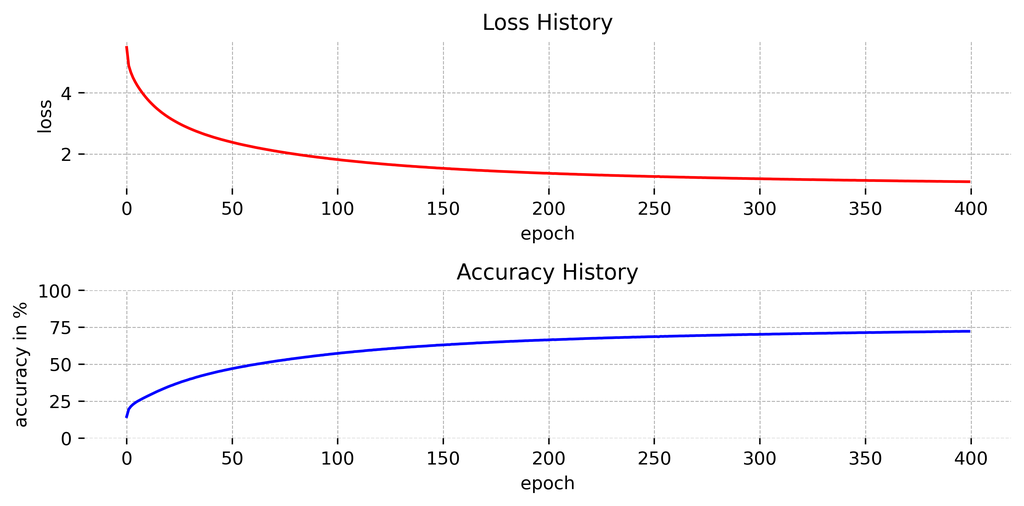

```python
attn_lstm.fit(optim, epochs, batch_size).plot()
```

```python
print(" ".join(attn_lstm.generate(*HarryPotterTokenDatasets.huge.tokens[:HarryPotterTokenDatasets.huge.context_size], length=500)))
print(" ".join(attn_lstm.generate(*HarryPotterTokenDatasets.huge.tokens[:HarryPotterTokenDatasets.huge.context_size], length=500, temperature=0.8, top_k=5)))
```

```
mister and miss dursley , of number four , privet drive , were proud to say that they were perfectly normal , thank you very much . they were the last people you loved him ! how long long month would 've you come to , you have known you would have been able to have been able to realize it would woul…
mister and miss dursley , of number four , privet drive , were proud to say that they were perfectly normal , thank you very much . they were the last people buying mistakes 's going have broken so powerful you expected not to have to remember ! '' ! bellowed , like him ... ... ... ... ... ... ... .…
```